```r
library(dplyr)
```

```r
library(ggplot2)
library(readr)
```

##Import data Creates summary file if it does not already exist

```r
source("C:/RProject/R-Deep-Learning-Essentials-Second-Edition/Chapter04/import.R")

# step 1, merge files
fileName <- import_data(data_directory,bExploreData=1)
```

[output not shown]

[output cut: 102 more lines]

##Read data

```r
t1<-Sys.time()
df<-read.csv(fileName,colClasses="character",
             header=TRUE,stringsAsFactors=FALSE)
nSize_df1<-object.size(df)
nSize_df1<-as.integer(nSize_df1/(1024*1024))
t2<-Sys.time()
diff1<-difftime(t2,t1,units="secs")
diff1<-as.integer(diff1)
dim(df)
```

```
## [1] 2541019      12
```

```r
head(df)
```

```
##         BASKET_ID      CUST_CODE SHOP_WEEK SHOP_DATE STORE_CODE QUANTITY SPEND
## 1 994100100398294 CUST0000410727    200607  20060415 STORE00001        1  0.93
## 2 994100100532898 CUST0000634693    200607  20060413 STORE00001        1  1.03
## 3 994100100398294 CUST0000410727    200607  20060415 STORE00001        1  3.07
## 4 994100100398294 CUST0000410727    200607  20060415 STORE00001        1  4.81
## 5 994100100532897 CUST0000634693    200607  20060412 STORE00001        1  0.28
## 6 994100100532898 CUST0000634693    200607  20060413 STORE00001        3  0.84
##    PROD_CODE PROD_CODE_10 PROD_CODE_20 PROD_CODE_30 PROD_CODE_40
## 1 PRD0900033      CL00201     DEP00067       G00021       D00005
## 2 PRD0900097      CL00001     DEP00001       G00001       D00001
## 3 PRD0900135      CL00201     DEP00067       G00021       D00005
## 4 PRD0900220      CL00051     DEP00013       G00005       D00002
## 5 PRD0900353      CL00070     DEP00020       G00007       D00002
## 6 PRD0900550      CL00167     DEP00055       G00016       D00003
```

```r
# convert numeric fields
df$QUANTITY<-as.numeric(df$QUANTITY)
df$SPEND<-as.numeric(df$SPEND)

# convert date field
df$SHOP_DATE <- as.Date(df$SHOP_DATE, "%Y%m%d")
```

##Data summaries Lets get some basic summaries

```r
nWeeks <- length(unique(df$SHOP_DATE))/7
nLines <- nrow(df)
nBaskets <- length(unique(df$BASKET_ID))
nCustomers <- length(unique(df$CUST_CODE))
nProducts <- length(unique(df$PROD_CODE))
nStores <- length(unique(df$STORE_CODE))
```

Number of weeks we have data: 117.  
Number of transaction lines: 2541019.  
Number of transactions (baskets): 390320.  
Number of unique Customers: 5000.  
Number of unique Products: 4997.  
Number of unique Stores: 761.

##Some graphs / data exploration In the following graphs, we want to ensure that the there is no gaps or outliers in the data. Because this is transactional data, we also expect to see some seasonal variations.

```r
# get summary stats
sumSalesByDate<-df %>%
  group_by(SHOP_DATE) %>%
  summarise(sales = sum(SPEND),
    qty = sum(QUANTITY),
    Cust = n_distinct(CUST_CODE),
    LineItems=n(),
    Trx = n_distinct(BASKET_ID),
    Products = n_distinct(PROD_CODE),
    Prod10 = n_distinct(PROD_CODE_10),
    Prod20 = n_distinct(PROD_CODE_20),
    Prod30 = n_distinct(PROD_CODE_30),
    Prod40 = n_distinct(PROD_CODE_40)
  )
sumSalesByDate$BasketSize<-sumSalesByDate$qty*1.0/sumSalesByDate$Trx
head(sumSalesByDate)
```

```
## # A tibble: 6 x 12
##   SHOP_DATE  sales   qty  Cust LineItems   Trx Products Prod10 Prod20 Prod30
##   <date>     <dbl> <dbl> <int>     <int> <int>    <int>  <int>  <int>  <int>
## 1 2006-04-10 5798.  4293   393      3057   436     1468    194     70     28
## 2 2006-04-11 5614.  4143   401      2844   448     1446    199     73     28
## 3 2006-04-12 5844.  4517   421      3166   463     1550    197     73     28
## 4 2006-04-13 5304.  4004   396      2794   430     1403    193     70     28
## 5 2006-04-14 4619.  3476   359      2498   397     1333    206     71     26
## 6 2006-04-15 6013.  4332   408      3046   445     1515    193     69     26
## # … with 2 more variables: Prod40 <int>, BasketSize <dbl>
```

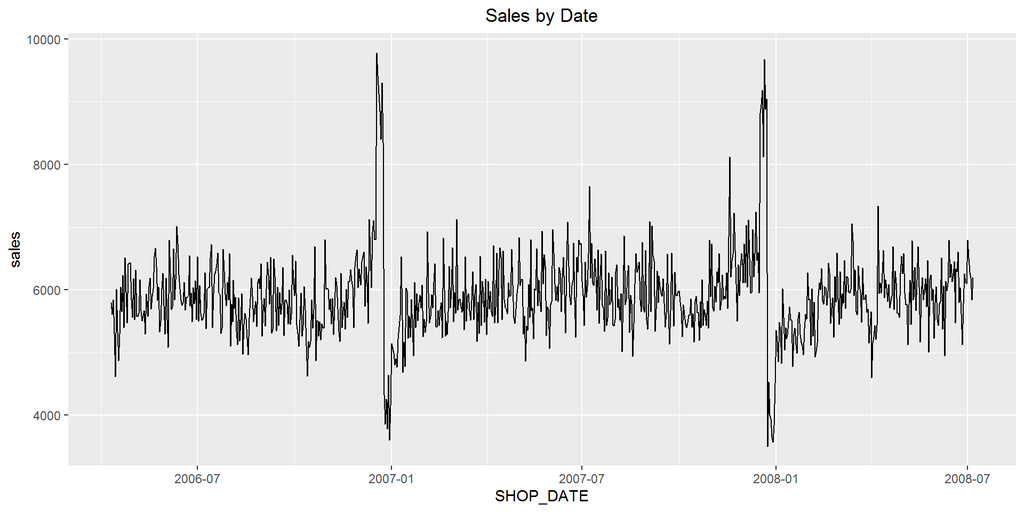

```r
qplot(SHOP_DATE,sales,data=sumSalesByDate,geom="line",main="Sales by Date")+
  theme(plot.title = element_text(hjust = 0.5))
```

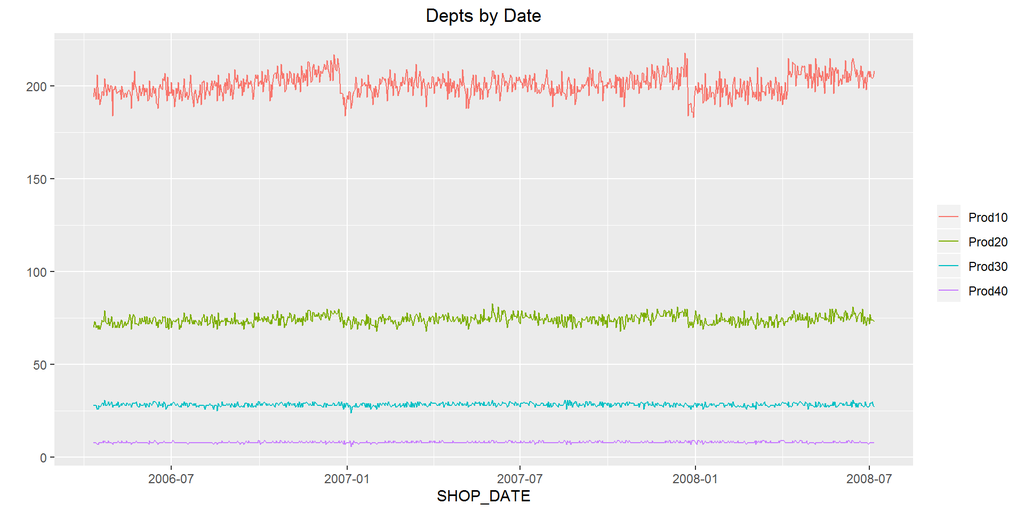

```r
ggplot(sumSalesByDate, aes(SHOP_DATE)) +
  ggtitle("Depts by Date") +
  ylab("") +
  theme(plot.title = element_text(hjust = 0.5)) +
  theme(legend.title = element_blank()) +
  geom_line(aes(y = Prod10, colour = "Prod10")) +
  geom_line(aes(y = Prod20, colour = "Prod20")) +
  geom_line(aes(y = Prod30, colour = "Prod30")) +
  geom_line(aes(y = Prod40, colour = "Prod40"))
```

This looks good. All the graph lines appear consistent, i.e. no spikes or zero values. We see peaks before Christmas and a decline in the early new year, which would be expected with transactional data.

Now, we should check the department codes. There are 5 product codes (“PROD_CODE”,“PROD_CODE_10”,“PROD_CODE_20”,“PROD_CODE_30”,“PROD_CODE_40”). We want to know the number of levels in each department code and if the codes are a true hierarchy

```r
sumSalesByProducts <- df %>%
  group_by(PROD_CODE,PROD_CODE_10,PROD_CODE_20,
           PROD_CODE_30,PROD_CODE_40) %>%
  summarise(sales = sum(SPEND)
  )

grp <- df %>%
  group_by(PROD_CODE,PROD_CODE_10) %>%
  summarise(count = n()
  )
nCheck0a <- nrow(grp)
nCheck0b <- nrow(unique(grp[,1]))

grp <- df %>%
  group_by(PROD_CODE_10,PROD_CODE_20) %>%
  summarise(count = n()
  )
nCheck1a <- nrow(grp)
nCheck1b <- nrow(unique(grp[,1]))

grp <- df %>%
  group_by(PROD_CODE_20,PROD_CODE_30) %>%
  summarise(count = n()
  )
nCheck2a <- nrow(grp)
nCheck2b <- nrow(unique(grp[,1]))

grp <- df %>%
  group_by(PROD_CODE_30,PROD_CODE_40) %>%
  summarise(count = n()
  )
nCheck3a <- nrow(grp)
nCheck3b <- nrow(unique(grp[,1]))

nCheck4b <- nrow(unique(grp[,2]))
```

PROD_CODE: Number of unique codes: 4997. Number of repeated codes: 0.  
PROD_CODE_10: Number of unique codes:250. Number of repeated codes: 0.  
PROD_CODE_20: Number of unique codes:90. Number of repeated codes: 0.  
PROD_CODE_30: Number of unique codes:31. Number of repeated codes: 0.  
PROD_CODE_40: Number of unique codes:9.

Department codes do not repeat, so the codes are a true hierarchy.

Size of data-frame after loading (MB):257  
Time to load data-frame (secs):16